# Experience, Portfolio and Suitability

Asset Modelling Data Scientist

Josh Cowley

j.cowley1@ncl.ac.uk

November 17, 2023

# Background

## Background

- Formally trained as a statistician, Newcastle University
  - MMathStat, Mathematics and Statistics (1st)
  - PhD in Statistics
- Always had an interest in “Computer Science”
- Discovered a career path that incorporates best of both worlds, **Data Science**

# Portfolio

# Advanced Laryngeal Cancer

## Advanced Laryngeal Cancer

Approached by Newcastle Hospitals NHS Foundation Trust.

The pseudonymised dataset contained:

1. survival times (date of diagnosis, death and last check-up)
2. clinical variables (age, smoking status, AJCC tumour status)
3. CT scan output (radiomic data), for a subset of patients

### Scope

Objectives were clear from the offset.

- Quantify impact of clinical predictors on survival times
- Delineate which radiomic features impact survival times
- Assess model improvement when CT data is available
- Publish results in scientific journal <sup>1</sup>
[^1]: Ongoing, currently with *“The Journal of Laryngology and Otology”*.

### Approach and Deliverables

Right-censored data, too many radiomic predictors.  
**Penalised Cox regression**, specifically LASSO.

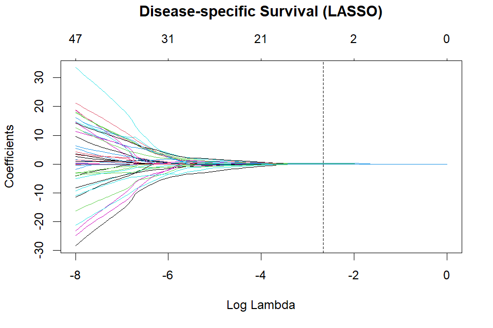

| Predictor | Hazard Ratio | CI (95%) | P-value |
| --- | --- | --- | --- |
| SHAPE Compacity | 2.616 | (1.073, 6.378) | 0.034 [*] |
| GLZLM GLNU | 1.120 | (0.607, 2.066) | 0.718 |
| $\dots$ | $\dots$ | $\dots$ | $\dots$ |
| Age | 1.067 | (1.012, 1.124) | 0.015 [*] |
| $\dots$ | $\dots$ | $\dots$ | $\dots$ |
| Treatment (Adjuvant) | 0.466 | (0.114, 1.908) | 0.288 |

10-fold Cross-validation was used to choose a penalty parameter value.

# English Housing Data

## English Housing Data

[Challenged](https://neecco.org.uk/all-events/annes-student-analysis-challenge/) with developing environmental sustainability indicators; full data science project.

- data collection
- data cleaning
- model building
- time management
- presentation of results
- encouraged reflection

[figure not shown]

### Scope

Investigate environmental health of English housing.

Key questions:

1. Are current metrics (EPC, SAP rating) suitable indicators?
2. Is dwelling efficiency impacted by region within the UK?

Open-source datasets considered: English housing survey (EHS), local authority housing data, and local authority emissions data.

### Approach

Intention was always to keep models simple.

### **Model A**

- Linear regression on efficiency or CO2 rating from EPC
- Regressed on key factors like boiler, insulation and more

### **Model B**

- Linear mixed effects model, intercept only
- Models overall mean and region-specific effect

### Deliverables

Presented key results to industry partners in May 2022.

Full report and source code available on GitHub.

- [Repository (nclJoshCowley/ANNE-challenge)](https://github.com/nclJoshCowley/ANNE-challenge/)
- [Environmental Impact of Housing in England, 2022 (report)](https://raw.githubusercontent.com/nclJoshCowley/ANNE-challenge/master/Environmental-impact-of-housing-in-england.pdf)

# Modelling Hydrocarbon Concentrations in Groundwater Monitoring Networks

## Modelling Hydrocarbon Concentrations in Groundwater Monitoring Networks

PhD studentship supported by Shell who:

- partially funded research
- provided groundwater monitoring data, specifically hydrocarbon concentrations (subject to NDA)
- communicated suggestions via monthly update meetings

### Data

Measurements require extracting sample, transport elsewhere.

- **Spatiotemporal**  
  Sampled annually to quarterly at pre-built “wells”
- **Environmental**  
  High degree of left-censoring
- **Complex**  
  Different geological, chemical, and political considerations

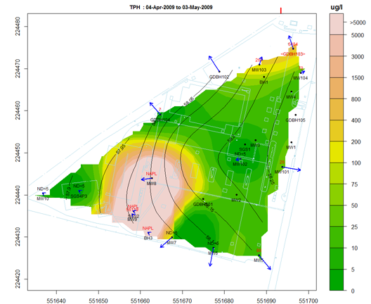

### Scope

1. **Analyte**
   - hydrocarbon concentration to be minimised
   - benzene (carcinogenic), toluene, ethylbenzene and more
2. **Predictor**
   - also available and easier data collection
   - temperature, pH, conductivity, dissolved oxygen, ORP

Our intentions were then to

- (*Optimistic*) describe an underlying relationship between analytes and predictors
- (*Realistic*) predict hydrocarbon concentrations using predictors, potentially with telemetry.

> Deeper insight into hydrocarbon concentrations using data analysis on already existing data to increase financial feasiblity.

### Approach

A lot of statistical models under supervisor guidance.

- Multiple and multivariate regression <sup>1</sup>
- Tobit regression
- Matrix normal regression
- Mixture of experts
- Varying intercept, spatial prior
[^2]: Dependent variable censored values replaced with half detection limit.

### Deliverables

- Very little signal in the data compared to noise
- Aiming to have a letter to the editor, describing findings
- Models to become open source <sup>1</sup>, potentially CRAN packages
- More research needed for other water quality variables, say iron
- Advised Shell against exploring telemetry with these predictors
[^3]: https://github.com/nclJoshCowley/bmoe